# Tutorial 11 – Model Selection

### This notebook contains all the sample code and solutions to the model assessment for model selection.

Model selection has two levels: for one model, how to choose its hyperparameters (Sections 1-3); among different models, which model to use (Section 4).

#### You will learn:

1. The use of validation dataset
2. Linear regression models with regularizations.
3. Post pruning decision tree with complexity penalty
4. Hyperparameter search with GridSearchCV
5. Choosing between models: cross-validation and hold-out

### Summary of toolbox:

1. pruning decision trees: cost_complexity_pruning_path https://scikit-learn.org/stable/auto_examples/tree/plot_cost_complexity_pruning.html
2. Support vector machine for classification: from sklearn.svm import SVC https://scikit-learn.org/stable/modules/generated/sklearn.svm.SVC.html
3. GridSearch CV: from sklearn.model_selection import GridSearchCV https://scikit-learn.org/stable/modules/generated/sklearn.model_selection.GridSearchCV.html
4. Classification report: from sklearn.metrics import classification_report https://scikit-learn.org/stable/modules/generated/sklearn.metrics.classification_report.html

# 1. Overfitting and Ridge Regression

In this section we first show that a complex model fits the training data very well but performs badly on new data (**overfitting**). We then use **Ridge regression** to penalize large coefficients, and use the validation set to choose the penalty strength.

Flow: generate data (1.1) → overfitting with a complex model (1.2) → Ridge regression (1.3) → choose the penalty α (1.4)

reference: https://www.analyticsvidhya.com/blog/2016/01/ridge-lasso-regression-python-complete-tutorial/

## 1.1 Generate the Data

Let's first generate a dataset from y = sin(x) + noise. The true pattern is a smooth curve, and the noise makes the points deviate from it. We then extend x into 15 polynomial features (x, x², ..., x¹⁵), split the data into training and validation sets, and normalize the features.

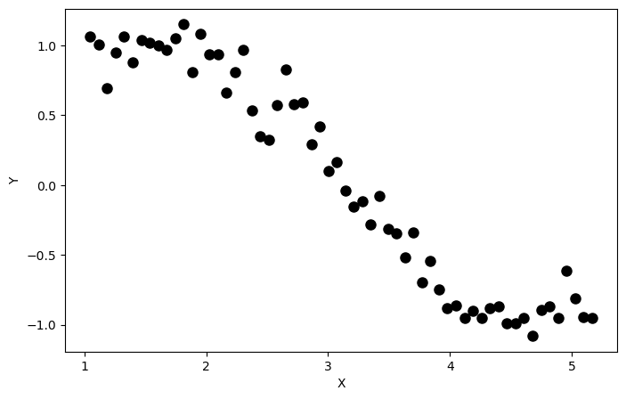

|  | x | y | x^2 | x^3 | x^4 | x^5 | x^6 | x^7 | x^8 | x^9 | x^10 | x^11 | x^12 | x^13 | x^14 | x^15 |
| --- | --- | --- | --- | --- | --- | --- | --- | --- | --- | --- | --- | --- | --- | --- | --- | --- |
| 0 | 1.047198 | 1.065763 | 1.096623 | 1.148381 | 1.202581 | 1.259340 | 1.318778 | 1.381021 | 1.446202 | 1.514459 | 1.585938 | 1.660790 | 1.739176 | 1.821260 | 1.907219 | 1.997235 |
| 1 | 1.117011 | 1.006086 | 1.247713 | 1.393709 | 1.556788 | 1.738948 | 1.942424 | 2.169709 | 2.423588 | 2.707173 | 3.023942 | 3.377775 | 3.773011 | 4.214494 | 4.707635 | 5.258479 |
| 2 | 1.186824 | 0.695374 | 1.408551 | 1.671702 | 1.984016 | 2.354677 | 2.794587 | 3.316683 | 3.936319 | 4.671717 | 5.544505 | 6.580351 | 7.809718 | 9.268760 | 11.000386 | 13.055521 |
| 3 | 1.256637 | 0.949799 | 1.579137 | 1.984402 | 2.493673 | 3.133642 | 3.937850 | 4.948448 | 6.218404 | 7.814277 | 9.819710 | 12.339811 | 15.506664 | 19.486248 | 24.487142 | 30.771450 |
| 4 | 1.326450 | 1.063496 | 1.759470 | 2.333850 | 3.095735 | 4.106339 | 5.446854 | 7.224981 | 9.583578 | 12.712139 | 16.862020 | 22.366630 | 29.668222 | 39.353420 | 52.200353 | 69.241170 |

```python
#Importing libraries. The same will be used throughout the article.
import numpy as np
import pandas as pd
import random
import matplotlib.pyplot as plt
%matplotlib inline
from matplotlib.pylab import rcParams
plt.figure(figsize=(8,5))
#Define input array with angles from 60deg to 300deg converted to radians
x = np.array([i*np.pi/180 for i in range(60,300,4)])
np.random.seed(10)  #Setting seed for reproducibility
y = np.sin(x) + np.random.normal(0,0.15,len(x))
data = pd.DataFrame(np.column_stack([x,y]),columns=['x','y'])
plt.plot(data['x'],data['y'],".",color='black',markersize=16)
plt.xlabel('X')
plt.ylabel('Y')
plt.show()

#create new variables for x^k
for i in range(2,16):  #power of 1 is already there
    colname = 'x^%d'%i      #new var will be x_power
    data[colname] = data['x']**i
data.head()
```

```python
from sklearn.model_selection import train_test_split
from sklearn.metrics import mean_absolute_error
from sklearn.preprocessing import MinMaxScaler,Normalizer
power=15
predictors=['x']
predictors.extend(['x^%d'%i for i in range(2,power+1)])#we extend the orignial feature x to the power of 2, 3, ..., 15
X_train, X_test, y_train, y_test = train_test_split(data[predictors], data['y'], random_state=0)

feature_scaler = MinMaxScaler()
X_train_N=feature_scaler.fit_transform(X_train) #normalize X_train
X_test_N=feature_scaler.transform(X_test) #normalize X_test using min and max of X_train

X_train=pd.DataFrame(X_train_N,columns=list(X_train))
X_test=pd.DataFrame(X_test_N,columns=list(X_test))
```

## 1.2 Overfitting: Polynomial Regression

A complex model can fit the training data very well, but it may have an overfitting issue: it learns the noise instead of the true pattern.

For example, we can use **polynomial regression**:

$$y=a0+a1*x + a2*x^2+a3*x^3+...a15*x^{15}$$

Below we check the training error, the size of the coefficients, and the validation error.

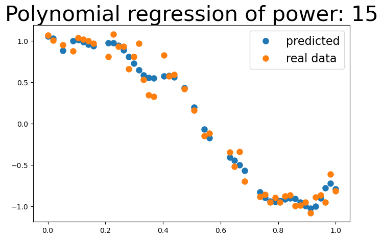

```python
from sklearn.linear_model import LinearRegression

plt.figure(figsize=(8,5))

power=15

linreg = LinearRegression() #set up the model.
#the regressor X will be normalized before regression.
#The normalization will be done by subtracting the mean and dividing it by L2 norm.
linreg.fit(X_train,y_train)
y_pred_train = linreg.predict(X_train)

plt.plot(X_train['x'],y_pred_train,'.',markersize=16)
plt.plot(X_train['x'],y_train,'.',markersize=16)
plt.title('Polynomial regression of power: %d'%power,fontsize=30)
plt.legend(['predicted','real data'],fontsize=16)
plt.show()
```

Let's take a look at the training error and coefficients from this fitting.

The training error is small. But the coefficients are very large.

```python
print('Training Error= %f' %mean_absolute_error(y_train, y_pred_train))
print('intercept=%f' %linreg.intercept_)
for i in range(len(linreg.coef_)):
    print('a%d=%f' %(i+1,linreg.coef_[i]))
```

```
Training Error= 0.078421
intercept=1.057933
a1=2031913.488968
a2=-36773928.509989
a3=344864790.122914
a4=-2126062340.662427
a5=9336994579.702747
a6=-30327783622.518524
a7=74302988106.380981
a8=-138560140803.835876
a9=196821717578.505493
a10=-211394249905.825348
a11=168725679119.933807
a12=-96954767996.357971
a13=37897523973.656570
a14=-9017406266.972521
a15=985384801.042269
```

What about validation error? The validation performance is bad.

```
Validation Error= 0.230047
```

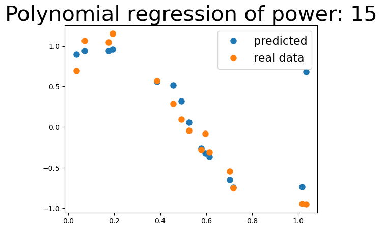

```python
y_pred = linreg.predict(X_test)
print('Validation Error= %f' %mean_absolute_error(y_test, y_pred))
plt.plot(X_test['x'],y_pred,'.',markersize=16)
plt.plot(X_test['x'],y_test,'.',markersize=16)
plt.title('Polynomial regression of power: %d'%power,fontsize=30)
plt.legend(['predicted','real data'],fontsize=16)
plt.show()
```

## 1.3 Ridge Regression: Penalizing Large Coefficients

Ridge regression adds a penalty on the size of the coefficients, so the model cannot use very large coefficients to chase the noise.

Regression penalty: α * (sum of square of coefficients)

Here we fix the penalty α = 0.1 and compare with the polynomial regression above.

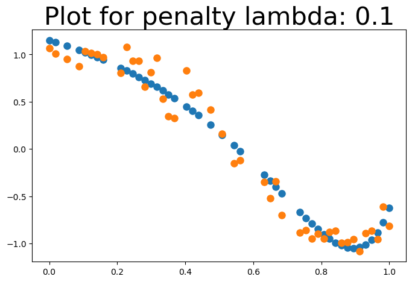

```python
from sklearn.linear_model import Ridge
plt.figure(figsize=(8,5))

alpha=0.1 #the penlty term is set to be 0.1
#Fit the model
ridgereg = Ridge(alpha=alpha)
ridgereg.fit(X_train,y_train)
y_pred_train = ridgereg.predict(X_train)


#Check if a plot is to be made for the entered alpha
plt.plot(X_train['x'],y_pred_train,'.',markersize=16)
plt.plot(X_train['x'],y_train,'.',markersize=16)
plt.title('Plot for penalty lambda: %.3g'%alpha,fontsize=30)
plt.show()
```

Let's take a look at the training error and coefficients from this fitting.

The training error is larger. But the coefficients are significantly reduced. The model is reduced to a simpler form.

```python
print('Training Error= %f' %mean_absolute_error(y_train, y_pred_train))
print('intercept=%f' %ridgereg.intercept_)
for i in range(len(ridgereg.coef_)):
    print('a%d=%f' %(i+1,ridgereg.coef_[i]))
```

```
Training Error= 0.126277
intercept=1.150080
a1=-0.641983
a2=-0.977411
a3=-0.936037
a4=-0.702257
a5=-0.422426
a6=-0.171054
a7=0.025460
a8=0.164427
a9=0.252661
a10=0.299650
a11=0.314658
a12=0.305680
a13=0.279223
a14=0.240404
a15=0.193162
```

```
Validation Error= 0.196034
```

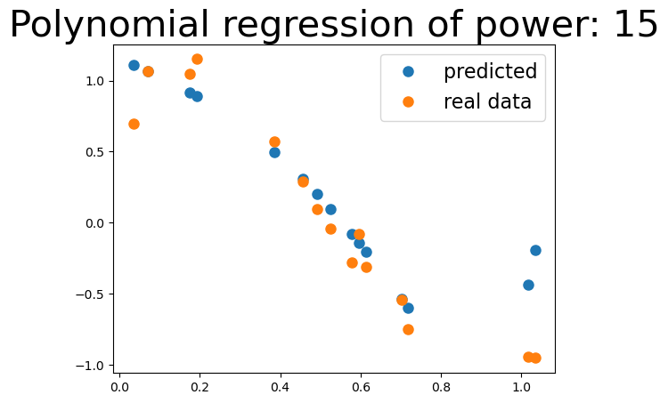

```python
#The model complexity was controled. What about validation performance?
y_pred = ridgereg.predict(X_test)
print('Validation Error= %f' %mean_absolute_error(y_test, y_pred))
plt.plot(X_test['x'],y_pred,'.',markersize=16)
plt.plot(X_test['x'],y_test,'.',markersize=16)
plt.title('Polynomial regression of power: %d'%power,fontsize=30)
plt.legend(['predicted','real data'],fontsize=16)
plt.show()
```

## 1.4 Choose the Penalty α with the Validation Set

α controls the strength of the penalty: α = 0 means no penalty (the same as ordinary linear regression), and a larger α gives a simpler model. We try a range of α values and compare their validation errors.

```python
alpha_test=[i/100 for i in range(0,20)] #search this hyperparameter from 0 to 0.19, with a step of 0.01

for alpha in alpha_test:
    ridgereg = Ridge(alpha=alpha).fit(X_train,y_train)
    y_pred = ridgereg.predict(X_test)
    print(alpha,'Validation Error= %f' %mean_absolute_error(y_test, y_pred))
```

```
0.0 Validation Error= 0.230049
0.01 Validation Error= 0.161678
0.02 Validation Error= 0.176549
0.03 Validation Error= 0.183870
0.04 Validation Error= 0.188023
0.05 Validation Error= 0.190702
0.06 Validation Error= 0.192492
0.07 Validation Error= 0.193629
0.08 Validation Error= 0.194661
0.09 Validation Error= 0.195472
0.1 Validation Error= 0.196034
0.11 Validation Error= 0.196411
0.12 Validation Error= 0.196648
0.13 Validation Error= 0.196780
0.14 Validation Error= 0.196828
0.15 Validation Error= 0.196811
0.16 Validation Error= 0.196747
0.17 Validation Error= 0.196745
0.18 Validation Error= 0.196716
0.19 Validation Error= 0.196664
```

### which alpha provides the best performance?

# 2. Post pruning decision trees with complexity penalty for Breast Cancer Diagnostic

[Reference](https://scikit-learn.org/stable/auto_examples/tree/plot_cost_complexity_pruning.html#sphx-glr-auto-examples-tree-plot-cost-complexity-pruning-py)

**Dataset:** UCI ML Breast Cancer Wisconsin (Diagnostic), downloaded from https://goo.gl/U2Uwz2

- Features are computed from a digitized image of a fine needle aspirate (FNA) of a breast mass.
- They describe characteristics of the cell nuclei present in the image.

```python
import matplotlib.pyplot as plt
from sklearn.model_selection import train_test_split
from sklearn.datasets import load_breast_cancer
from sklearn.tree import DecisionTreeClassifier
```

We load the attributes and class label for each digitized image of a fine needle aspirate (FNA) of a breast mass. The detailed measurement of a cell can be found here: [data description](https://scikit-learn.org/stable/datasets/toy_dataset.html#breast-cancer-dataset)

```python
cancer = load_breast_cancer()

df_feat = pd.DataFrame(cancer['data'],
                       columns = cancer['feature_names'])

# cancer column is our target
df_target = pd.DataFrame(cancer['target'],
                     columns =['Cancer'])
```

```python
df_feat.head()
```

|  | mean radius | mean texture | mean perimeter | mean area | mean smoothness | mean compactness | mean concavity | mean concave points | mean symmetry | mean fractal dimension | ... | worst radius | worst texture | worst perimeter | worst area | worst smoothness | worst compactness | worst concavity | worst concave points | worst symmetry | worst fractal dimension |
| --- | --- | --- | --- | --- | --- | --- | --- | --- | --- | --- | --- | --- | --- | --- | --- | --- | --- | --- | --- | --- | --- |
| 0 | 17.99 | 10.38 | 122.80 | 1001.0 | 0.11840 | 0.27760 | 0.3001 | 0.14710 | 0.2419 | 0.07871 | ... | 25.38 | 17.33 | 184.60 | 2019.0 | 0.1622 | 0.6656 | 0.7119 | 0.2654 | 0.4601 | 0.11890 |
| 1 | 20.57 | 17.77 | 132.90 | 1326.0 | 0.08474 | 0.07864 | 0.0869 | 0.07017 | 0.1812 | 0.05667 | ... | 24.99 | 23.41 | 158.80 | 1956.0 | 0.1238 | 0.1866 | 0.2416 | 0.1860 | 0.2750 | 0.08902 |
| 2 | 19.69 | 21.25 | 130.00 | 1203.0 | 0.10960 | 0.15990 | 0.1974 | 0.12790 | 0.2069 | 0.05999 | ... | 23.57 | 25.53 | 152.50 | 1709.0 | 0.1444 | 0.4245 | 0.4504 | 0.2430 | 0.3613 | 0.08758 |
| 3 | 11.42 | 20.38 | 77.58 | 386.1 | 0.14250 | 0.28390 | 0.2414 | 0.10520 | 0.2597 | 0.09744 | ... | 14.91 | 26.50 | 98.87 | 567.7 | 0.2098 | 0.8663 | 0.6869 | 0.2575 | 0.6638 | 0.17300 |
| 4 | 20.29 | 14.34 | 135.10 | 1297.0 | 0.10030 | 0.13280 | 0.1980 | 0.10430 | 0.1809 | 0.05883 | ... | 22.54 | 16.67 | 152.20 | 1575.0 | 0.1374 | 0.2050 | 0.4000 | 0.1625 | 0.2364 | 0.07678 |

5 rows × 30 columns

```python
df_target.head()
```

|  | Cancer |
| --- | --- |
| 0 | 0 |
| 1 | 0 |
| 2 | 0 |
| 3 | 0 |
| 4 | 0 |

```python
#randomly split the dataset. By default, the test_size=0.25
X_train, X_test, y_train, y_test = train_test_split(df_feat, np.ravel(df_target), random_state=0)
```

## 2.1 Generate Candidate Penalties α

```python
clf = DecisionTreeClassifier(random_state=0)
path = clf.cost_complexity_pruning_path(X_train, y_train) #seeking alpha
ccp_alphas, impurities = path.ccp_alphas, path.impurities #output apha and tree impurities

fig, ax = plt.subplots()
ax.plot(ccp_alphas[:-1], impurities[:-1], marker="o", drawstyle="steps-post")
ax.set_xlabel("effective alpha")
ax.set_ylabel("total impurity of leaves")
ax.set_title("Total Impurity vs effective alpha for training set")
```

[output not shown]

## 2.2 Train a Tree for Each α

For each α from 2.1, we train a decision tree with `ccp_alpha=α` and store it in a list. This gives us a set of trees with different complexity.

```python
clfs = [] #this list will be used to store a list of Decision Tree Models with different penalty alpha values.
for alpha in ccp_alphas:
    print('the penalty term alpha is %f' %alpha)
    clf = DecisionTreeClassifier(random_state=0, ccp_alpha=alpha) # induce a tree using the ccp_alpha value
    clf.fit(X_train, y_train)
    clfs.append(clf)
```

```
the penalty term alpha is 0.000000
the penalty term alpha is 0.002266
the penalty term alpha is 0.004647
the penalty term alpha is 0.004660
the penalty term alpha is 0.005634
the penalty term alpha is 0.007042
the penalty term alpha is 0.007842
the penalty term alpha is 0.009114
the penalty term alpha is 0.011444
the penalty term alpha is 0.018988
the penalty term alpha is 0.023142
the penalty term alpha is 0.034225
the penalty term alpha is 0.327298
```

### 2.2.1 Example Trees

The first tree uses the first penalty α (ccp_alphas[0] = 0), so it is the full tree without pruning. The next two plots show the tree with the 5-th α and the last α (the tree is pruned to only the root).

```
the first alphas is:  0.0
```

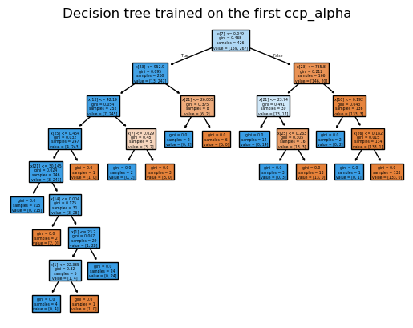

```python
from sklearn.tree import plot_tree
print('the first alphas is: ', ccp_alphas[0]) #the first alpha value in the list of ccp_alphas generated.
plot_tree(clfs[0], filled=True)
plt.title("Decision tree trained on the first ccp_alpha")
plt.show()
```

```
the 5th alphas is:  0.007042253521126761
```

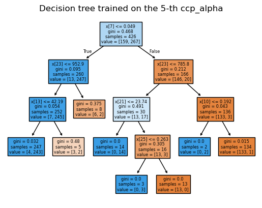

```python
print('the 5th alphas is: ', ccp_alphas[5])
plot_tree(clfs[5], filled=True)
plt.title("Decision tree trained on the 5-th ccp_alpha")
plt.show()
```

```
the last alphas is:  0.3272984419327777
```

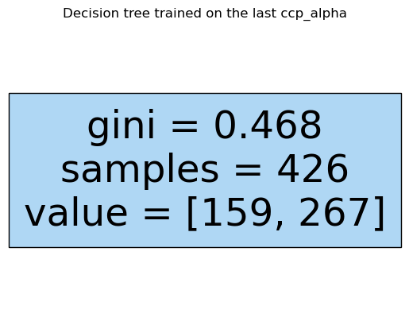

```python
print('the last alphas is: ', ccp_alphas[-1])
plot_tree(clfs[-1], filled=True)
plt.title("Decision tree trained on the last ccp_alpha")
plt.show()
```

## 2.3 Tree Complexity vs. α

We count the number of nodes and the depth of each tree. Both decrease as α increases: a larger penalty gives a simpler tree. (The last tree, which only has the root, is excluded.)

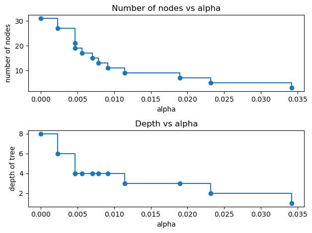

```python
clfs = clfs[:-1]
ccp_alphas = ccp_alphas[:-1]

node_counts = [clf.tree_.node_count for clf in clfs]
depth = [clf.tree_.max_depth for clf in clfs]
fig, ax = plt.subplots(2, 1)
ax[0].plot(ccp_alphas, node_counts, marker="o", drawstyle="steps-post")
ax[0].set_xlabel("alpha")
ax[0].set_ylabel("number of nodes")
ax[0].set_title("Number of nodes vs alpha")
ax[1].plot(ccp_alphas, depth, marker="o", drawstyle="steps-post")
ax[1].set_xlabel("alpha")
ax[1].set_ylabel("depth of tree")
ax[1].set_title("Depth vs alpha")
fig.tight_layout()
fig
```

## 2.4 Conclusion

- The penalty α controls the complexity of a decision tree: a larger α prunes more branches and gives a smaller tree (fewer nodes and a smaller depth).
- This is the same idea as Ridge regression in Section 1, where a larger α gives smaller coefficients and a simpler model.
- α is a hyperparameter. A tree with α = 0 is fully grown and may overfit, while a very large α leaves only the root. To choose a good α, we need to compare the performance of the trees on validation data. Next, we learn how to search hyperparameters automatically with GridSearchCV.

# 3. Automatic Hyperparameter Search: GridSearchCV

In Section 1 we looped over α by hand and compared the validation errors ourselves. In Section 2 we generated candidate α values, but did not choose one. In this section, `GridSearchCV` does it automatically: it tries every combination of the hyperparameters we give, evaluates each one with cross-validation on the training set, and picks the best.

We use the same breast cancer training/test split as in Section 2, and the model is a support vector machine (SVC).

## 3.1 Baseline: SVC with Default Parameters

First train an SVC with the default parameters and check its performance on the test set. This is the baseline for the tuned model.

```python
from sklearn.svm import SVC
from sklearn.model_selection import GridSearchCV
from sklearn.metrics import classification_report
```

```python
# train the model on train set
model = SVC()
model.fit(X_train, y_train)

# print prediction results
predictions = model.predict(X_test)
print(classification_report(y_test, predictions))
```

```
              precision    recall  f1-score   support

           0       0.98      0.85      0.91        53
           1       0.92      0.99      0.95        90

    accuracy                           0.94       143
   macro avg       0.95      0.92      0.93       143
weighted avg       0.94      0.94      0.94       143
```

## 3.2 GridSearchCV: Search C and gamma Automatically

- **C** (penalty for misclassified points) and **gamma** (reach of a single training point in the `rbf` kernel) control the complexity of SVC, like α in the previous sections.
- `param_grid` lists the values to try: 5 × 5 = 25 combinations. Each one is evaluated by 5-fold cross-validation on the training set (explained in Section 4), and the best one is refitted on the whole training set.

```python
from sklearn.model_selection import GridSearchCV

# defining hyperparameter options
param_grid = {'C': [0.1, 1, 10, 100, 1000],
              'gamma': [1, 0.1, 0.01, 0.001, 0.0001],
              'kernel': ['rbf']}

grid = GridSearchCV(SVC(), param_grid, refit = True, verbose = 3)

# fitting the model for grid search
grid.fit(X_train, y_train)
```

```
Fitting 5 folds for each of 25 candidates, totalling 125 fits
[CV 1/5] END ........C=0.1, gamma=1, kernel=rbf;, score=0.628 total time=   0.0s
[CV 2/5] END ........C=0.1, gamma=1, kernel=rbf;, score=0.635 total time=   0.0s
[CV 3/5] END ........C=0.1, gamma=1, kernel=rbf;, score=0.624 total time=   0.0s
[CV 4/5] END ........C=0.1, gamma=1, kernel=rbf;, score=0.624 total time=   0.0s
[CV 5/5] END ........C=0.1, gamma=1, kernel=rbf;, score=0.624 total time=   0.0s
[CV 1/5] END ......C=0.1, gamma=0.1, kernel=rbf;, score=0.628 total time=   0.0s
[CV 2/5] END ......C=0.1, gamma=0.1, kernel=rbf;, score=0.635 total time=   0.0s
[CV 3/5] END ......C=0.1, gamma=0.1, kernel=rbf;, score=0.624 total time=   0.0s
[CV 4/5] END ......C=0.1, gamma=0.1, kernel=rbf;, score=0.624 total time=   0.0s
[CV 5/5] END ......C=0.1, gamma=0.1, kernel=rbf;, score=0.624 total time=   0.0s
[CV 1/5] END .....C=0.1, gamma=0.01, kernel=rbf;, score=0.628 total time=   0.0s
[CV 2/5] END .....C=0.1, gamma=0.01, kernel=rbf;, score=0.635 total time=   0.0s
[CV 3/5] END .....C=0.1, gamma=0.01, kernel=rbf;, score=0.624 total time=   0.0s
[CV 4/5] END .....C=0.1, gamma=0.01, kernel=rbf;, score=0.624 total time=   0.0s
[CV 5/5] END .....C=0.1, gamma=0.01, kernel=rbf;, score=0.624 total time=   0.0s
[CV 1/5] END ....C=0.1, gamma=0.001, kernel=rbf;, score=0.628 total time=   0.0s
[CV 2/5] END ....C=0.1, gamma=0.001, kernel=rbf;, score=0.635 total time=   0.0s
[CV 3/5] END ....C=0.1, gamma=0.001, kernel=rbf;, score=0.624 total time=   0.0s
[CV 4/5] END ....C=0.1, gamma=0.001, kernel=rbf;, score=0.624 total time=   0.0s
[CV 5/5] END ....C=0.1, gamma=0.001, kernel=rbf;, score=0.624 total time=   0.0s
[CV 1/5] END ...C=0.1, gamma=0.0001, kernel=rbf;, score=0.953 total time=   0.0s
[CV 2/5] END ...C=0.1, gamma=0.0001, kernel=rbf;, score=0.894 total time=   0.0s
[CV 3/5] END ...C=0.1, gamma=0.0001, kernel=rbf;, score=0.906 total time=   0.0s
[CV 4/5] END ...C=0.1, gamma=0.0001, kernel=rbf;, score=0.906 total time=   0.0s
[CV 5/5] END ...C=0.1, gamma=0.0001, kernel=rbf;, score=0.941 total time=   0.0s
[CV 1/5] END ..........C=1, gamma=1, kernel=rbf;, score=0.628 total time=   0.0s
[CV 2/5] END ..........C=1, gamma=1, kernel=rbf;, score=0.635 total time=   0.0s
[CV 3/5] END ..........C=1, gamma=1, kernel=rbf;, score=0.624 total time=   0.0s
[CV 4/5] END ..........C=1, gamma=1, kernel=rbf;, score=0.624 total time=   0.0s
[CV 5/5] END ..........C=1, gamma=1, kernel=rbf;, score=0.624 total time=   0.0s
[CV 1/5] END ........C=1, gamma=0.1, kernel=rbf;, score=0.628 total time=   0.0s
[CV 2/5] END ........C=1, gamma=0.1, kernel=rbf;, score=0.635 total time=   0.0s
[CV 3/5] END ........C=1, gamma=0.1, kernel=rbf;, score=0.624 total time=   0.0s
[CV 4/5] END ........C=1, gamma=0.1, kernel=rbf;, score=0.624 total time=   0.0s
[CV 5/5] END ........C=1, gamma=0.1, kernel=rbf;, score=0.624 total time=   0.0s
[CV 1/5] END .......C=1, gamma=0.01, kernel=rbf;, score=0.628 total time=   0.0s
[CV 2/5] END .......C=1, gamma=0.01, kernel=rbf;, score=0.635 total time=   0.0s
[CV 3/5] END .......C=1, gamma=0.01, kernel=rbf;, score=0.624 total time=   0.0s
[CV 4/5] END .......C=1, gamma=0.01, kernel=rbf;, score=0.624 total time=   0.0s
```

[output cut: 71 more lines]

```
[CV 1/5] END ....C=1000, gamma=0.01, kernel=rbf;, score=0.628 total time=   0.0s
[CV 2/5] END ....C=1000, gamma=0.01, kernel=rbf;, score=0.647 total time=   0.0s
[CV 3/5] END ....C=1000, gamma=0.01, kernel=rbf;, score=0.624 total time=   0.0s
[CV 4/5] END ....C=1000, gamma=0.01, kernel=rbf;, score=0.635 total time=   0.0s
[CV 5/5] END ....C=1000, gamma=0.01, kernel=rbf;, score=0.612 total time=   0.0s
[CV 1/5] END ...C=1000, gamma=0.001, kernel=rbf;, score=0.953 total time=   0.0s
[CV 2/5] END ...C=1000, gamma=0.001, kernel=rbf;, score=0.906 total time=   0.0s
[CV 3/5] END ...C=1000, gamma=0.001, kernel=rbf;, score=0.882 total time=   0.0s
[CV 4/5] END ...C=1000, gamma=0.001, kernel=rbf;, score=0.929 total time=   0.0s
[CV 5/5] END ...C=1000, gamma=0.001, kernel=rbf;, score=0.918 total time=   0.0s
[CV 1/5] END ..C=1000, gamma=0.0001, kernel=rbf;, score=0.942 total time=   0.0s
[CV 2/5] END ..C=1000, gamma=0.0001, kernel=rbf;, score=0.906 total time=   0.0s
[CV 3/5] END ..C=1000, gamma=0.0001, kernel=rbf;, score=0.953 total time=   0.0s
[CV 4/5] END ..C=1000, gamma=0.0001, kernel=rbf;, score=0.941 total time=   0.0s
[CV 5/5] END ..C=1000, gamma=0.0001, kernel=rbf;, score=0.906 total time=   0.0s
```

```
GridSearchCV(estimator=SVC(),
             param_grid={'C': [0.1, 1, 10, 100, 1000],
                         'gamma': [1, 0.1, 0.01, 0.001, 0.0001],
                         'kernel': ['rbf']},
             verbose=3)
```

```python
# print best parameter after tuning
print(grid.best_params_)

# print how our model looks after hyper-parameter tuning
print(grid.best_estimator_)
```

```
{'C': 1, 'gamma': 0.0001, 'kernel': 'rbf'}
SVC(C=1, gamma=0.0001)
```

```python
grid_predictions = grid.predict(X_test)

# print classification report
print(classification_report(y_test, grid_predictions))
```

```
              precision    recall  f1-score   support

           0       0.92      0.92      0.92        53
           1       0.96      0.96      0.96        90

    accuracy                           0.94       143
   macro avg       0.94      0.94      0.94       143
weighted avg       0.94      0.94      0.94       143
```

## 3.3 Default vs. Tuned SVC

Both models are evaluated on the same test set (143 samples). The test set is only used for the final evaluation; the tuned parameters are selected by cross-validation on the training set.

|  | Baseline (default SVC) | Tuned SVC (GridSearchCV) |
| --- | --- | --- |
| Parameters | C=1, gamma='scale' | C=1, gamma=0.0001 |
| Accuracy | 0.937 | 0.944 |
| Class 0 precision / recall | 0.98 / 0.85 | 0.92 / 0.92 |
| Class 1 precision / recall | 0.92 / 0.99 | 0.96 / 0.96 |
| Macro avg F1 | 0.93 | 0.94 |

- The accuracy improves only slightly, but the tuned model is more balanced: the recall of class 0 increases from 0.85 to 0.92.
- The numbers may differ slightly with a different scikit-learn version.

# 4. Choosing Between Models

In Sections 1-3 we tuned the parameters of one model. Model selection also includes choosing **which model** to use: we evaluate each candidate model on data it has not been trained on, and pick the best one.

There are different ways to evaluate a model. Here we use two of them:

- **Cross-validation** (4.1, 4.2): the score is averaged over several train/validation splits, so it is more stable.
- **Hold-out** (4.3): split the data once into training and test sets.

We use stratified Cross Validation to evaluate a 3-class classification problem using the iris dataset.

Details of CV, please check documentation: https://scikit-learn.org/stable/modules/cross_validation.html#cross-validation-iterators

[figure not shown]

```python
import numpy as np
import pandas as pd
import matplotlib.pyplot as plt
from matplotlib.colors import ListedColormap
from sklearn.model_selection import train_test_split
from sklearn.preprocessing import StandardScaler
from sklearn.datasets import make_moons, make_circles, make_classification
from sklearn.neural_network import MLPClassifier
from sklearn.neighbors import KNeighborsClassifier
from sklearn.svm import SVC
from sklearn.gaussian_process import GaussianProcessClassifier
from sklearn.gaussian_process.kernels import RBF
from sklearn.tree import DecisionTreeClassifier
from sklearn.ensemble import RandomForestClassifier, AdaBoostClassifier
from sklearn.naive_bayes import GaussianNB
from sklearn.discriminant_analysis import QuadraticDiscriminantAnalysis
```

```python
data = pd.read_csv('iris.txt',header=None)  #use tool "read_csv" to read the data in "iris.txt" file. the data is stored in "data"
data.columns = ['sepal length', 'sepal width', 'petal length', 'petal width', 'class'] #set the column names of the data table
data.head(10) #
```

|  | sepal length | sepal width | petal length | petal width | class |
| --- | --- | --- | --- | --- | --- |
| 0 | 5.1 | 3.5 | 1.4 | 0.2 | Iris-setosa |
| 1 | 4.9 | 3.0 | 1.4 | 0.2 | Iris-setosa |
| 2 | 4.7 | 3.2 | 1.3 | 0.2 | Iris-setosa |
| 3 | 4.6 | 3.1 | 1.5 | 0.2 | Iris-setosa |
| 4 | 5.0 | 3.6 | 1.4 | 0.2 | Iris-setosa |
| 5 | 5.4 | 3.9 | 1.7 | 0.4 | Iris-setosa |
| 6 | 4.6 | 3.4 | 1.4 | 0.3 | Iris-setosa |
| 7 | 5.0 | 3.4 | 1.5 | 0.2 | Iris-setosa |
| 8 | 4.4 | 2.9 | 1.4 | 0.2 | Iris-setosa |
| 9 | 4.9 | 3.1 | 1.5 | 0.1 | Iris-setosa |

```python
Y = data['class'] #this is our prediction target
X = data.drop(['class'],axis=1)
```

## 4.1 Cross-validation Score of Two Models

`cross_val_score` returns the score of each fold. A model with a higher score (on average) generalizes better.

```python
from sklearn.model_selection import cross_val_score
clf=KNeighborsClassifier(10)
scores = cross_val_score(clf, X, Y, cv=5)
print('KNN CV Score:', scores)
```

```
KNN CV Score: [0.96666667 1.         1.         0.93333333 1.        ]
```

```python
clf=DecisionTreeClassifier(max_depth=10)
scores = cross_val_score(clf, X, Y, cv=5)
print('DT CV Score:', scores)
```

```
DT CV Score: [0.96666667 0.96666667 0.9        0.93333333 1.        ]
```

## 4.2 Compare All the Models

Run the same cross-validation for 10 different classifiers and compare their scores.

```python
h = 0.02  # step size in the mesh

names = [
    "Nearest Neighbors",
    "Linear SVM",
    "RBF SVM",
    "Gaussian Process",
    "Decision Tree",
    "Random Forest",
    "Neural Net",
    "AdaBoost",
    "Naive Bayes",
    "QDA",
]

classifiers = [
    KNeighborsClassifier(10),
    SVC(kernel="linear", C=0.025),
    SVC(gamma=2, C=1),
    GaussianProcessClassifier(1.0 * RBF(1.0)),
    DecisionTreeClassifier(max_depth=5),
    RandomForestClassifier(max_depth=5, n_estimators=10, max_features=1),
    MLPClassifier(alpha=1, max_iter=1000),
    AdaBoostClassifier(),
    GaussianNB(),
    QuadraticDiscriminantAnalysis(),
]
```

```python
for i in range(len(classifiers)):
    clf=classifiers[i] #use the i-th model in the "classifiers" list
    scores = cross_val_score(clf, X, Y, cv=5)
    print('CV Score of '+ names[i], scores)
```

```
CV Score of Nearest Neighbors [0.96666667 1.         1.         0.93333333 1.        ]
CV Score of Linear SVM [0.93333333 0.96666667 0.9        0.93333333 1.        ]
CV Score of RBF SVM [0.96666667 1.         0.9        0.96666667 1.        ]
CV Score of Gaussian Process [0.96666667 1.         0.93333333 0.93333333 1.        ]
CV Score of Decision Tree [0.96666667 0.96666667 0.9        0.93333333 1.        ]
CV Score of Random Forest [0.96666667 0.96666667 0.93333333 0.9        1.        ]
CV Score of Neural Net [1.         1.         0.96666667 0.96666667 1.        ]
CV Score of AdaBoost [0.96666667 0.93333333 0.9        0.93333333 1.        ]
CV Score of Naive Bayes [0.93333333 0.96666667 0.93333333 0.93333333 1.        ]
CV Score of QDA [1.         1.         0.96666667 0.93333333 1.        ]
```

## 4.3 Hold-out with Classification Report

Instead of cross-validation, we can split the data once into training and test sets, and look at the precision, recall and F1-score of each class.

```python
from sklearn.metrics import classification_report # this library directly generates precision, recall, f-measure
from sklearn.model_selection import train_test_split

clf=DecisionTreeClassifier(max_depth=10)
X_train, X_test, y_train, y_test = train_test_split(X, Y, test_size=0.33, random_state=1)
clf.fit(X_train,y_train)
y_pred=clf.predict(X_test)

print(classification_report(y_test, y_pred))
```

```
                 precision    recall  f1-score   support

    Iris-setosa       1.00      1.00      1.00        17
Iris-versicolor       0.95      0.95      0.95        19
 Iris-virginica       0.93      0.93      0.93        14

       accuracy                           0.96        50
      macro avg       0.96      0.96      0.96        50
   weighted avg       0.96      0.96      0.96        50
```

For multi-class classification problem, micro-average precision scores can be defined as sum of true positives for all the classes divided by the all positive predictions. The positive prediction is sum of all true positives and false positives. Here is how it would look like mathematically:

$𝑃𝑟𝑒𝑐𝑖𝑠𝑖𝑜𝑛𝑀𝑖𝑐𝑟𝑜𝐴𝑣𝑔=\frac{(𝑇𝑃_1+𝑇𝑃_2+𝑇𝑃_3)}{(𝑇𝑃_1+𝑇𝑃_2+𝑇𝑃_3+𝐹𝑃_1+𝐹𝑃_2+𝐹𝑃_3)}$

Macro-average precision score can be defined as the arithmetic mean of all the precision scores of different classes. Here is how it would look like mathematically:

$𝑃𝑟𝑒𝑐𝑖𝑠𝑖𝑜𝑛𝑀𝑎𝑐𝑟𝑜𝐴𝑣𝑔=\frac{(𝑃𝑟𝑒𝑐_1+𝑃𝑟𝑒𝑐_2+𝑃𝑟𝑒𝑐_3)}{3}$

# Summary

## 1. Overfitting and Ridge regression

- Overfitting: a complex model fits the training data well but performs badly on new data.
- Ridge regression penalizes large coefficients (`Ridge(alpha=...)`), and the validation set is used to choose α.
- `from sklearn.linear_model import LinearRegression, Ridge`
- `from sklearn.metrics import mean_absolute_error`

## 2. Post pruning decision trees

- A larger α (`ccp_alpha`) gives a smaller tree.
- `cost_complexity_pruning_path` generates the candidate α values.

## 3. Automatic hyperparameter search

- `GridSearchCV` tries all the parameter combinations (here C and gamma of `SVC`) with cross-validation and selects the best.
- `from sklearn.model_selection import GridSearchCV`

## 4. Choosing between models

- Compare different models with cross-validation (`cross_val_score`) or hold-out (`classification_report`).
- `from sklearn.model_selection import cross_val_score`
- `from sklearn.metrics import classification_report`

# Assignment Week 11

1. Use the Breast Cancer Wisconsin (Diagnostic) dataset to select the best model among Decision Trees, RandomForest, and SVC that has the minimum testing error (use the default model settings) (40 points).
2. Use the same dataset and try to use nested Cross-validation to get the optimal hyperparameters for each model, and then compare the model performance (40 points).
3. What other BDA process can you use to further improve the performance of the best models in Question 2? For example, feature selection or dimension reduction, imbalanced data sampling, etc., Please evaluate. (20 points).